# Introduktion til Python til Dataanalyse

Denne lektion gennemgår hvordan Python anvendes til dataanalyse. Der introduceres især til data frames i Python biblioteket "pandas".

# Hvad er Python?

Python er et programmeringssprog. At arbejde med Python kræver derfor, at man “taler” det rette sprog, når man gerne vil have Python til at gøre noget.

Python har ikke en brugerflade, så for at få Python til at gøre noget, skal vi “fortælle” Python, hvad vi gerne vil ved at skrive kommandoer i Python sproget.

## Interager med Python

Barberes Python ned til sine grundsten består det ikke af mere end en “interpreter” (fortolker). Alle programmeringssprog er bygget op om en fortolker, der “evaluerer” kommandoer. Inden for programmering vil evaluering sige, at sproget forsøger at forstå, hvad der står i en kommando.

Man kan arbejde med Python fortolkeren direkte igennem en terminal/kommandoprompt, men det gør det meget besværligt at arbejde med.

## Python i Jupyter Lab / Jupyter Notebook

I dette kursus bruger vi Jupyter Lab som vores program (IDE) til at arbejde med Python: https://jupyter.org/

Jupyter Lab/Notebook er opbygget omkring en såkaldt “notebook”. En notebook i Jupyter kombinerer Python kode med almindelig tekst (skrevet i “Markdown”). Jupyter Notebook egner sig særdeles godt, hvis man skal dokumentere sit kodearbejde undervejs, da man har mulighed for at skrive almindelig tekst, sætte billeder ind, lave tabeller osv. omkring sin kode.

# Fundamentale koncepter i Python

Som nævnt arbejder man med Python ved at skrive kommandoer i Python sproget. Kommandoer bliver “evalueret” af fortolkeren. Hvis koden forstås, bliver den kørt, og der gives et output, en ændring eller andet afhængigt af, hvad man beder om.

```python
42 + 4
```

```
46
```

## Objekter/varaible

Python er et objekt-orienteret programmeringssprog. Dette indebærer, at man kontinuerligt arbejder med forskellige objekter, som indeholder en eller anden for for information.

I Python kaldes objekter “variable”. Dette er ikke at forveksle med en variabel, som forstået i statistik som en egenskab ved en observation, da en variabel i Python blot er en beholder for en eller anden form for information.

```python
number = 42
print(number + 2)
```

```
44
```

```python
name = "kenobi"
print(name)
```

```
kenobi
```

## Funktioner

En central del af det at arbejde med et programmeringssprog er at bruge funktioner. Funktioner tager et eller flere input (kaldet “argumenter”), foretager et eller andet med disse og returnerer (for det meste) et output.

Funktioner i Python har følgende format:

```
function(argument1, argument2, ...)
```

```python
print("hello", "there", sep = ", ")
```

```
hello, there
```

## Metoder

Udover funktioner i Python findes der også “metoder”. Lig funktioner tager metoder også en form for input og returnerer et output.

I modsætning til funktioner er metoder bundet op på bestemte variabeltyper. Det vil sige at variablen skal være en bestemt type for, at metoden kan bruges. Metoder kaldes med `variabel.method(option1 = something)`. Tekstværdier (strings) har fx en række metoder tilknyttet til at ændre teksten:

```python
name = "kenobi"
name.upper()
```

```
'KENOBI'
```

## Pakker

Pakker i Python er samlinger af funktioner, metoder, værdier osv. Selvom man kan meget i Python, så når man ikke særlig langt uden at importere pakker.

Funktioner, metoder, værdier osv. fra pakker kan nemt indlæses ved at importere dem. Så snart pakken er importeret, er pakkens indhold tilgængeligt.

```python
import math

print(math.pi)
```

```
3.141592653589793
```

# ØVELSE 0: KAN PYTHON NOGET?

- Lav en notebook til denne lektion
- Lav en kodecelle
- Skriv kommandoen `print("hello there")` ind i cellen
- Kør cellen

# Data og datasæt

I disse Python lektioner gennemgås, hvordan Python anvendes til dataanalyse, men hvad er data overhovedet for noget?

Som udgangspunkt arbejder vi med en meget bred forståelse af data: alle former for information om noget. Grunden til at der i dag er så meget snak om data, dataanalyse, maskinlæring osv., er fordi at stadig mere og mere information digitaliseres, hvorfor det kan gøres til genstand for analyser.

Navn, alder, uddannelse, indkomst, yndlingsfilm, mest aflyttede sange i 2020, antal gange rejst med bus 2 i Aalborg, køb i supermarkeder, størrelse på bolig, indbo, brug af el, varme og vand osv. Alle disse informationer er data og alt sammen kan indgå i analyser til at sige noget om en person eller, mere relevant, flere personer med lignende karakteristika.

Data som en mere eller mindre tilfældig strøm af tilfældig information er vanskelig at arbejde med. Data skal på en eller anden måde være i system for, at det kan analyseres - det gælder både maskinel/computationel analyse eller menneskelig analyse.

Når man taler om et datasæt, mener man typisk en eller anden form for afgrænset mængde data, der måske eller måske ikke er struktureret i en eller anden form.

## Struktureret og ustruktureret data

Man adskiller typisk mellem struktureret og ustruktureret data.

**Struktureret data**

*Struktureret data* er data, der på en eller anden måde er sat i system. Den klassiske repræsentation af struktureret data er i et tabulært format, hvor hver række indeholder en *observation* og hver kolonne indeholder en *variabel* (eller "feature", som det omtales inden for maskinlæring. En observation kan være en person, et land, et firma, et tidspunkt, en kommune osv., mens en variabel er en eller anden form for information om observationen.

Tabellen herunder er et eksempel på struktureret data:

| Navn | Alder | Beskæftigelse |
| --- | --- | --- |
| Lars | 34 | Slagter |
| Gertrud | 62 | Rådgiver |
| Henning | 43 | Revisor |
| Agnes | 38 | Tømrer |

Struktureret data er kendeteget ved at være sat i system sådan, at man umiddelbart kan analysere og spørge data om noget. I ovenstående tabel kan man fx meget hurtigt undersøge, hvor mange der er ældre end 40, hvem der har et fornavn der starter med "H" eller hvem der har beskæftigelse inden for byggeri.

**Ustruktureret data**

*Ustruktureret data* er data, som - kort sagt - ikke er sat i system. Hvis data ikke er struktureret, vil man typisk kalde det ustruktureret data. Tekst, billeder og video er typiske eksempler på ustruktureret data, da disse blot er rå information uden nogen måde at adskille en type information fra en anden. Mange moderne dataanalyseteknikker fokuserer på ustruktureret data, hvor man enten udvikler teknikker til at skabe overblik over ustruktureret data eller forsøger at give data en form for struktur.

Nedenstående er et eksempel på ustruktureret data:

```
["Hvorfor går man ikke i dialog med @DRC_dk i stedet for at opsige kontrakten uden varsel. Er det kun for at føre stærk mand politik? DRC yder en fremragende indsats på baggrund af den opgave de har fået #dkpol https://jyllands-posten.dk/indland/ECE12248020/tesfaye-forsoeger-sig-med-en-ny-loesning-paa-alle-udlaendingeministres-problem/ …",
"Alle tæller ❤️ https://twitter.com/cekicozlem/status/1276034922587832326 …",
"Det er så godt arbejde💚 https://twitter.com/fannybroholm/status/1275360842847080449 …",
"Tilfreds med den klima og energiaftale, der er lavet nu. Det er den første delaftale om at nå 70% reduktion i 2030. Særligt glad for at den indeholder principaftale om en CO2 afgiftsreform #dkpol #dkgreen pic.twitter.com/3slrMxLT5B",
"Godt første skridt for den fri natur #dkpol #dkgreen @alternativet_ https://www.altinget.dk/miljoe/artikel/wermelin-lander-aftale-om-de-foerste-naturnationalparker …",
"Spændende udmelding. @alternativet_ ønsker også en grøn   Klimaafgift, hvor udgangspunktet er at forureneren betaler #dkgreen #dkpol https://www.altinget.dk/artikel/venstre-og-radikale-laegger-faelles-pres-paa-regeringen-vil-have-ensartet-co2-afgift?SNSubscribed=true&ref=newsletter&refid=fredag-middag-190620&utm_campaign=altingetdk%20Altinget.dk&utm_medium%09=e-mail&utm_source=nyhedsbrev …",
"Så vigtigt at KL tager ansvar for den proces #dkpol #dkgreen https://www.altinget.dk/miljoe/artikel/professor-om-affaldsaftale-kl-og-kommunerne-skal-gribe-chancen-for-at-loese-tingene-selv …",
"Hurra - stor dag for Danmark💚👏🏼👏🏼 https://twitter.com/alternativet_/status/1273555055476723713 …",
"Til klimaforhandlinger i Finansministeriet. Vi sidder og diskuterer rammerne - de næste dage bliver intensive #dkpol #dkgreen @alternativet_ @ Christiansborg Palace  https://www.instagram.com/p/CBi3d0oB9lB/?igshid=ii78cjnx2n72 …",
"Aftale om mindre affald, mindre forbrænding og mere genbrug - god dag for klimaet og miljøet. 1. skridt i en stor miljøpakke #dkpol @alternativet_ https://www.dr.dk/nyheder/indland/live-regeringen-praesenterer-ny-aftale-om-affald …"]
```

I ovenstående kan man stadig overføre ideen om observationer (i dette tilfælde tweets fra danske politikere), men der er ingen variable eller features givet på forhånd. Der er derfor ingen umiddelbar struktur at gøre brug af for at foretage sig analyser.

## Fra data til dataanalyse

Uanset om data er struktureret eller ustruktureret, er de næsten aldrig klar til at analysere med det samme. Data skal næsten altid tilpasses den analyse, som man ønsker at foretage og de spørgsmål, som man ønsker at få svar på med sin analyse.

For struktureret data indebærer dette at få identificeret de relevante dele af sine data (er det fx alle observationer, der er relevante?) samt undersøge og rekode variable sådan, at de meningsfuldt kan bruges i sin analyse.

For ustruktureret data indebærer det på en eller anden måde at få sat system i eller skabt overblik over data.

Ofte vil man også arbejde med data fra flere kilder, hvorfor en del forarbejde også kan gå med at få data kombineret i et samlet datasæt.

## VIDENSCHECK

*Hvilke af nedenstående er eksempler på datasæt?:*

- Navnet på butikschefen i det lokale supermarked
- Alle værker af H.C. Andersen
- En oversigt over medlemmer af DFØJ med information om navn, fødselsår, arbejdssted og uddannelse
- Filmen "Vampire's Kiss" med Nicolas Cage fra 1988
- Et kontoudtog
- Alle film med Nicolas Cage

# Introduktion til pandas

Pakken `pandas` (https://pandas.pydata.org/) er et Python bibliotek til datahåndtering og dataanalyse. Pandas egner sig særligt til data i tabeller struktureret i rækker og kolonner. En datatabel kaldes inden for pandas en "DataFrame"; et bestemt Python objekt specifikt til at lagre og bearbejde data i tabeller.

Denne lektion gennemgår diverse basale funktioner til at indlæse, udforske og håndtere en pandas DataFrame. Se også den officielle dokumentation for flere guides, introduktioner og beskrivelser til at arbejde med pandas: https://pandas.pydata.org/docs/

## Indlæs data med `pandas`

`pandas` pakken indeholder funktioner til at indlæse data i forskellige formater; herunder CSV, JSON, Excel, Stata, SAS osv.

```python
import pandas as pd

ess2018 = pd.read_csv("https://github.com/CALDISS-AAU/course_ndms-I/raw/master/datasets/ESS2018DK_subset.csv")
```

*Bemærk importkonventionerne for `pandas`. `pandas` typisk som `pd`.*

**Navngivning af datasæt**

Der er forskellige præferencer og holdninger til, hvordan man bør navngive sine objekter.

Som hovedregel bør man gå efter navne, som både er relativt korte (man kan ende med at skulle skrive det mange gange) og som er sigende for, hvad objektet indeholder.

Dog kan man også argumentere for at navngive meget generisk, sådan at ens kode kan anvendes på andet data.

### Om datasættet

Datasættet, som indlæses her, er et uddrag af datasættet fra European Social Survey (ESS) 2018 (https://www.europeansocialsurvey.org/).

ESS er en europæisk surveyundersøgelse, der gentages hvert andet år. Surveyet behandler spørgsmål om folks helbred, beskæftigelse, politiske holdninger, tillid osv. I dette uddrag er der kun inkluderet de danske respondenter og et mindre udpluk variable.

Subsettet af ESS 2018 indeholder følgende kolonner:

| variable | description |
| --- | --- |
| idno | Respondent's identification number |
| netustm | Internet use, how much time on typical day, in minutes |
| ppltrst | Most people can be trusted or you can't be too careful |
| vote | Voted last national election |
| prtvtddk | Party voted for in last national election, Denmark |
| lvpntyr | Year first left parents for living separately for 2 months or more |
| tygrtr | Retire permanently, age too young. SPLIT BALLOT |
| gndr | Gender |
| yrbrn | Year of birth |
| edlvddk | Highest level of education, Denmark |
| eduyrs | Years of full-time education completed |
| wkhct | Total contracted hours per week in main job overtime excluded |
| wkhtot | Total hours normally worked per week in main job overtime included |
| grspnum | What is your usual [weekly/monthly/annual] gross pay |
| frlgrsp | Fair level of [weekly/monthly/annual] gross pay for you |
| inwtm | Interview length in minutes, main questionnaire |

## Inspicer data med `pandas`

Datasættet er nu indlæst som et dataframe objekt i Python, som man kan interagere med.

Metoden `.head()` printer de første fem rækker af datasættet:

```python
ess2018.head()
```

|  | idno | netustm | ppltrst | vote | prtvtddk | lvpntyr | tygrtr | gndr | yrbrn | edlvddk | eduyrs | wkhct | wkhtot | grspnum | frlgrsp | inwtm |
| --- | --- | --- | --- | --- | --- | --- | --- | --- | --- | --- | --- | --- | --- | --- | --- | --- |
| 0 | 110 | 180.0 | 8.0 | Yes | Socialdemokratiet - The Social democrats | 1968 | Never too young | Male | 1949 | Kort videregående uddannelse af op til 2-3 års... | 9.0 | 28.0 | 28.0 | NaN | NaN | 119.0 |
| 1 | 705 | 60.0 | 5.0 | Yes | Det Konservative Folkeparti - Conservative Peo... | 1976 | 67 | Male | 1958 | Kort videregående uddannelse af op til 2-3 års... | 22.0 | 37.0 | 45.0 | NaN | NaN | 55.0 |
| 2 | 1327 | 240.0 | 5.0 | NaN | NaN | Still in parental home, never left 2 months | NaN | Male | 2000 | Folkeskole 9.-10. klasse | 11.0 | 37.0 | 37.0 | NaN | NaN | 37.0 |
| 3 | 3760 | 300.0 | 7.0 | Not eligible to vote | NaN | Still in parental home, never left 2 months | 40 | Male | 2002 | Folkeskole 9.-10. klasse | 9.0 | 2.0 | 2.0 | 200.0 | NaN | 43.0 |
| 4 | 4658 | 90.0 | 8.0 | Yes | NaN | 1974 | 50 | Female | 1956 | Kort videregående uddannelse af op til 2-3 års... | 4.0 | 30.0 | 30.0 | NaN | NaN | 62.0 |

Dataframes er et tabulært dataformat. Når en fil indlæses som en pandas dataframe, skal filen derfor være i et format, der kan konverteres til tabelformat (data i rækker og kolonner).

**NaN?**

Som det ses af datasættet fremgår værdien `NaN` flere gange i datasættet (fx under kolonnen `prtvtddk`).

`NaN` angiver missingværdi. En missingværdi er en ikke-gyldig værdi; fx hvis en person ikke svarer, informationen ikke har været muligt at skaffe eller andet.

### Kolonner/variable

En dataframe består af en samling af kolonner. En kolonne i en dataframe kaldes en `series`.

Navnene på kolonnerne, som en dataframe indeholder, kan ses af attributen `.columns`:

```python
ess2018.columns
```

```
Index(['idno', 'netustm', 'ppltrst', 'vote', 'prtvtddk', 'lvpntyr', 'tygrtr',
       'gndr', 'yrbrn', 'edlvddk', 'eduyrs', 'wkhct', 'wkhtot', 'grspnum',
       'frlgrsp', 'inwtm'],
      dtype='object')
```

## Inspicer variable

En enkelt variabel/kolonne i datasættet referes til med `[]`:

```python
ess2018['lvpntyr'].head()
```

```
0                                           1968
1                                           1976
2    Still in parental home, never left 2 months
3    Still in parental home, never left 2 months
4                                           1974
Name: lvpntyr, dtype: object
```

Vi kan bruge en metode som `.value_counts()` til at optælle værdierne inden for én kolonne:

```python
ess2018['gndr'].value_counts()
```

```
Male      846
Female    726
Name: gndr, dtype: int64
```

Med funktionen `pd.crosstab()` kan vi opsummere over to variable:

```python
pd.crosstab(ess2018['gndr'], ess2018['prtvtddk'])
```

| prtvtddk gndr | Alternativet - The Alternative | Dansk Folkeparti - Danish People's Party | Det Konservative Folkeparti - Conservative People's Party | Det Radikale Venstre - The Radical Liberal Party | Enhedslisten - Unity List - The Red-Green Alliance | Kristendemokraterne - Christian Democrats | Liberal Alliance - Liberal Alliance | Other | SF Socialistisk Folkeparti - Socialist People's Party | Socialdemokratiet - The Social democrats | Venstre, Danmarks Liberale Parti - The Liberal Party |
| --- | --- | --- | --- | --- | --- | --- | --- | --- | --- | --- | --- |
| Female | 29 | 64 | 23 | 29 | 47 | 6 | 18 | 7 | 43 | 157 | 138 |
| Male | 24 | 108 | 29 | 43 | 44 | 9 | 30 | 9 | 30 | 181 | 162 |

# ØVELSE 1: INDLÆS DATA OG INSPICER VARIABLE

1. Indlæs datasættet `ESS2018DK_subset.csv` med `pd.read_csv()`, hvis du ikke allerede har gjort det.
   - Link til data: https://github.com/CALDISS-AAU/course_ndms-I/raw/master/datasets/ESS2018DK_subset.csv
2. Tjek at datasættet er indlæst korrekt med `.head()`
3. Brug `.value_counts()` til at finde ud af, hvor mange af respondenterne, der har "Lang videregående uddannelse" som deres højeste fuldførte uddannelse.

# Visualisering med `pandas`

`pandas` dataframes har en række indbyggede metoder til at plotte enkelte variable.

Plottingfunktionerne bruger pakken `matplotlib`, så gennem denne kan vi indstille størrelsen på plots:

```python
import matplotlib.pyplot as plt

%matplotlib inline

plt.rcParams['figure.figsize'] = (20.0, 10.0)
```

Vi kan fx bruge metoden `.plot.hist()` til at lave et histogram:

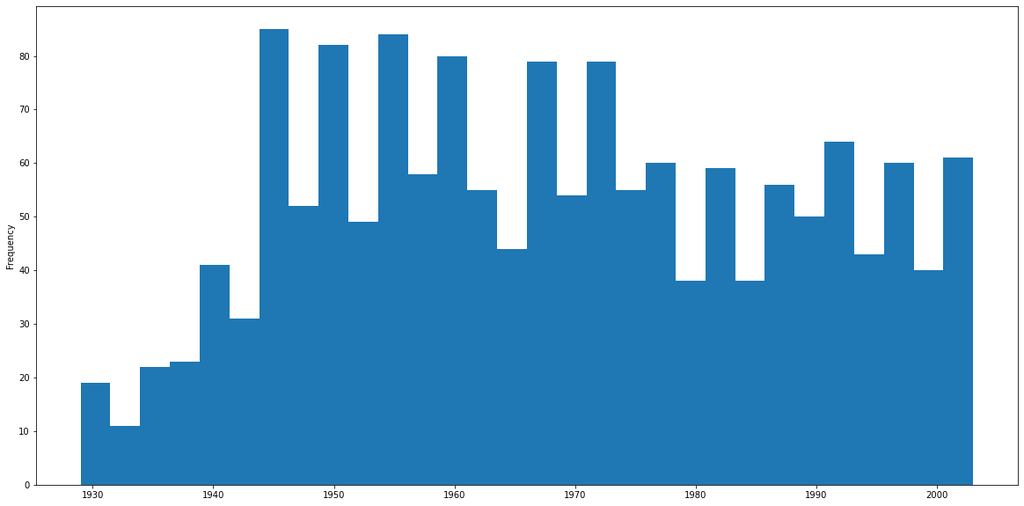

```python
ess2018['yrbrn'].plot.hist(bins = 30)
```

`.plot.box()` kan bruges til boxplots.

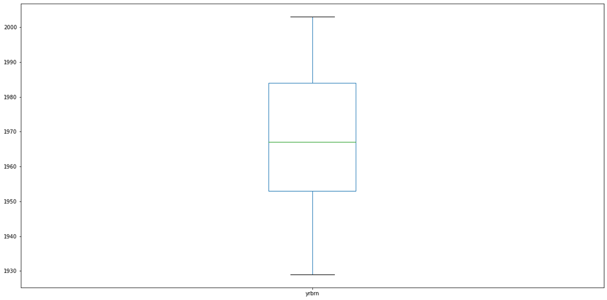

```python
ess2018['yrbrn'].plot.box()
```

`.plot.bar()` kan bruges til at lave søjlediagrammer over optællinger fra `.value_counts()` :

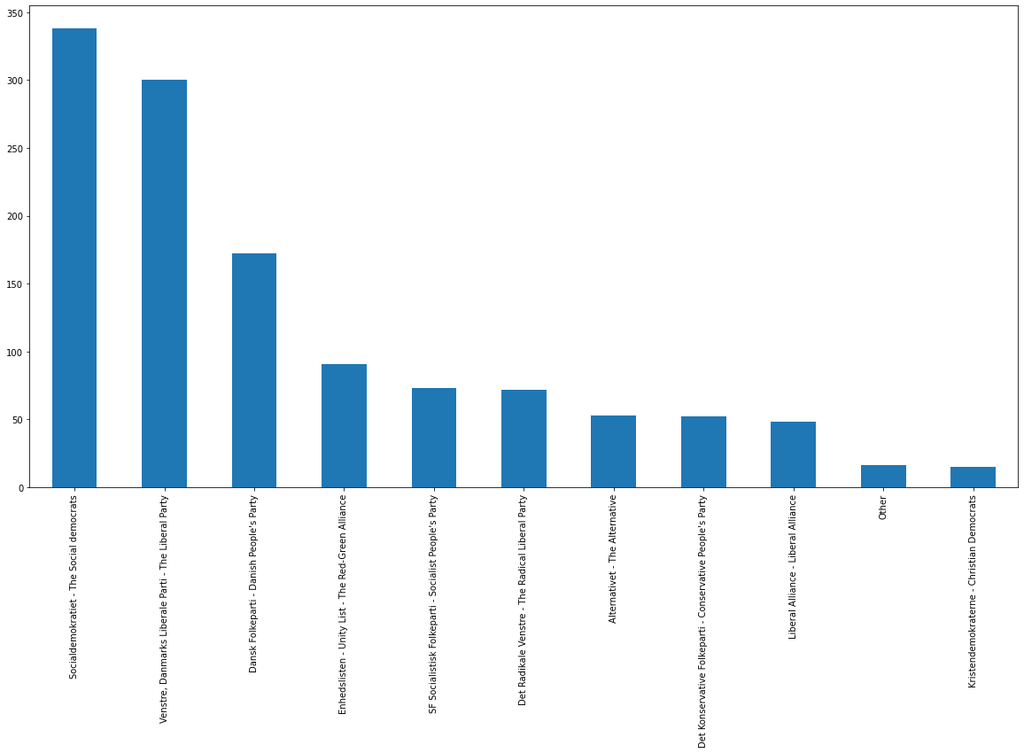

```python
ess2018['prtvtddk'].value_counts().plot.bar()
```

Alternativt en pie-chart med `.plot.pie()`. Denne kan med fordel kombineres med `.value_counts()`:

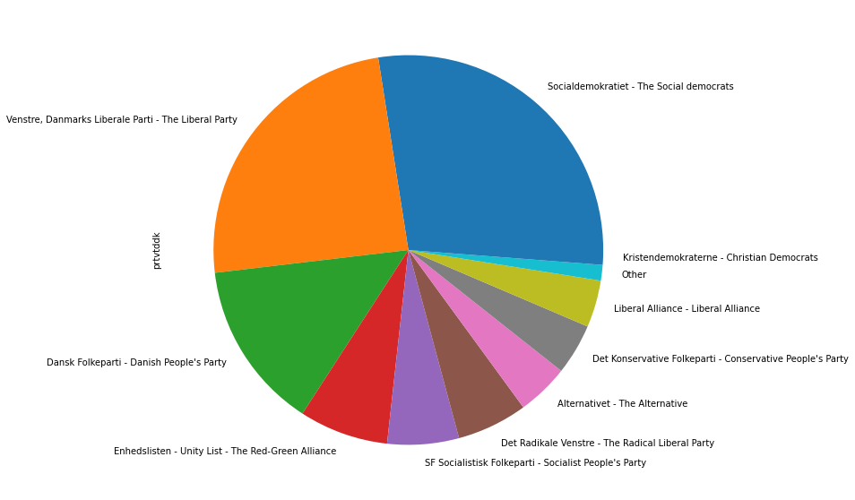

```python
ess2018['prtvtddk'].value_counts().plot.pie()
```

## Visualisering med `seaborn`

Der findes forskellige pakker til at lave visualisering i Python. En meget populær pakke er `seaborn`: https://seaborn.pydata.org/

Med `seaborn` kan man relativt nemt lave visualiseringer over flere variable.

I `seaborn` dannes plots ved først at refere specifikt til den plotting funtkion, som man vil bruge, og derefter specificere data.

Nedenstående linje danner et scatterplot for `yrbrn` (fødselsår) og `wkhtot` (antal arbejdstimer om ugen). Ved `seaborn` plottingfunktioner specificeres, hvilke værdier der skal udgøre x-aksen og hvilke, der skal udgøre y-aksen. `seaborn` forventer typisk series, så man kan specificere series direkte i funktionerne. Dog kan man også, som i nedenstående, specificere kolonne/variabelnavne og til sidst specificere data med argumentet `data =`:

```python
import seaborn as sns

sns.set(rc={'figure.figsize':(20,10)}) # Ændrer størrelsen af plots
```

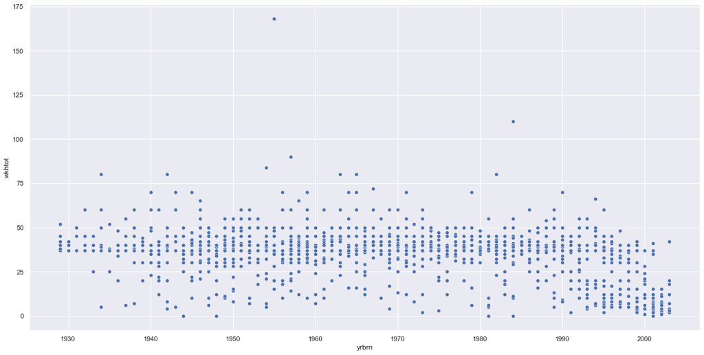

```python
sns.scatterplot(data = ess2018, x = 'yrbrn', y = 'wkhtot')
```

Et scatterplot danner en prik for hver observations placering på to variable. Plottet egner sig derfor særdeles godt til at udforske umiddelbare sammenhænge (om en variabel er beslægtet med en anden).

`seaborn` overskriver desuden standard grafindstillingerne i matplotlib, sådan at graferne bliver mere "moderne" at se på.

# ØVELSE 2: VISUALISERING AF DATA

1. Dan et histogram over variablen `grspnum` (selvrapporteret gennemsnitlig månedlige indkomst)
2. Dan et søjlediagram over optællinger over `edlvddk` (højest opnåede uddannelsesniveau)

# Deskriptive mål

Én måde at udforske et datasæt er ved at se nærmere på forskellige deskriptive mål for variable i datasættet.

Metoden `.describe()` danner deskriptive mål for alle (kompatible) variable i datasættet:

```python
ess2018.describe()
```

|  | idno | netustm | ppltrst | yrbrn | eduyrs | wkhct | wkhtot | grspnum | frlgrsp | inwtm |
| --- | --- | --- | --- | --- | --- | --- | --- | --- | --- | --- |
| count | 1572.000000 | 1395.000000 | 1568.000000 | 1572.000000 | 1559.000000 | 1448.000000 | 1502.000000 | 8.200000e+02 | 2.740000e+02 | 1566.000000 |
| mean | 110821.670483 | 232.204301 | 7.063138 | 1968.245547 | 13.678640 | 33.229282 | 36.171771 | 9.598654e+04 | 6.304640e+04 | 62.676884 |
| std | 26076.703893 | 193.175426 | 1.813012 | 19.188190 | 5.781205 | 10.568167 | 13.205436 | 2.935044e+05 | 1.616759e+05 | 24.774517 |
| min | 110.000000 | 0.000000 | 0.000000 | 1929.000000 | 0.000000 | 0.000000 | 0.000000 | 0.000000e+00 | 0.000000e+00 | 17.000000 |
| 25% | 93622.750000 | 90.000000 | 6.000000 | 1953.000000 | 11.000000 | 32.000000 | 34.000000 | 2.600000e+04 | 2.800000e+04 | 50.000000 |
| 50% | 112966.000000 | 180.000000 | 7.000000 | 1967.000000 | 14.000000 | 37.000000 | 37.000000 | 3.300000e+04 | 3.500000e+04 | 59.000000 |
| 75% | 131429.750000 | 330.000000 | 8.000000 | 1984.000000 | 17.000000 | 37.000000 | 42.000000 | 4.600000e+04 | 4.000000e+04 | 70.000000 |
| max | 150446.000000 | 1020.000000 | 10.000000 | 2003.000000 | 40.000000 | 80.000000 | 168.000000 | 5.000000e+06 | 1.500000e+06 | 613.000000 |

Metoden fungerer også på enkeltvariable:

```python
ess2018['wkhtot'].describe()
```

```
count    1502.000000
mean       36.171771
std        13.205436
min         0.000000
25%        34.000000
50%        37.000000
75%        42.000000
max       168.000000
Name: wkhtot, dtype: float64
```

`.describe()` danner følgende mål:

- `count`: Antal svar ekskl. missing
- `mean`: Middelværdien
- `std`: Standardafvigelsen
- `min`: Minimumværdien
- `25%`: 1. kvartil
- `50%`: 2. kvartil
- `75%`: 3. kvartil
- `max`: Maksimumværdien

Der knytter sig også en række metoder til at danne de enkelte deskriptive mål.

```python
print(ess2018['wkhtot'].mean())
print(ess2018['wkhtot'].std())
print(ess2018['wkhtot'].min())
print(ess2018['wkhtot'].max())
```

```
36.17177097203729
13.20543573826518
0.0
168.0
```

Ovenstående værdier fortæller, at `wkhtot` indeholder værdier fra 0.0 til 168.0 med en middelværdi på 36.17 og en standardafvigelse på 13.21 (middelværdien af de afstande, som hver observation afviger fra middelværdien).

## Deskriptive mål og kategoriske variable

Sammenlignes outputtet fra `.describe()` med indholdet af datasættet ses, at der ikke udregnes deskriptive mål for alle variable.

Når `.describe()` bruges på et hel dataframe, udregnes kun mål for numeriske variabeltyper; altså variable, der kun består af tal.

```python
ess2018['vote'].describe()
```

```
count     1566
unique       3
top        Yes
freq      1332
Name: vote, dtype: object
```

## Opsummeringer på gruppeniveau: Groupby

En effektiv måde at udforske og udføre indledende deskriptive analyser af sine data, er ved at undersøge de grupperinger, som data indeholder.

Her skal vi se på nogen forskellige måder, hvor der kan udregnes deskriptive mål og dannes visualiseringer for grupper i data

## Brug af split-apply til at opsummere data

Metoden `.groupby()` grupperer datasæt efter de givne variable:

```python
grouped_df = ess2018.groupby(['gndr'])
```

Selve objektet, som bliver dannet, indeholder ikke information, der bare kan kaldes frem direkte:

```python
grouped_df
```

```
<pandas.core.groupby.generic.DataFrameGroupBy object at 0x000001CB17F40948>
```

Dog kan vi danne de samme deskriptive mål, som vi kan for hele datasættet, men hvor de opsummeres på gruppeniveauet:

```python
grouped_df.mean()
```

| gndr | idno | netustm | ppltrst | yrbrn | eduyrs | wkhct | wkhtot | grspnum | frlgrsp | inwtm |
| --- | --- | --- | --- | --- | --- | --- | --- | --- | --- | --- |
| Female | 111135.282369 | 227.564669 | 7.140496 | 1967.834711 | 13.847010 | 31.939850 | 33.561404 | 53165.458689 | 45699.366667 | 64.078621 |
| Male | 110552.542553 | 236.069645 | 6.996437 | 1968.598109 | 13.534524 | 34.324393 | 38.354523 | 128033.880597 | 84030.717742 | 61.468490 |

Det samme kan gøres for enkeltvariable:

```python
grouped_df['wkhtot'].mean()
```

```
gndr
Female    33.561404
Male      38.354523
Name: wkhtot, dtype: float64
```

En lang række metoder kan bruges på grupperede data. Se dem alle her: https://pandas.pydata.org/pandas-docs/stable/user_guide/groupby.html.

- `mean()`: Middelværdi for grupperne
- `size()`: Størrelse af grupperne
- `count()`: Tællinger inden for grupperne
- `describe()`: Deskriptive mål inden for grupperne
- `min()`: Minimum for grupperne
- `max()`: Maximum for grupperne

Metoden `value_counts()` kan bruges til at lave optællinger af kategoriske inden for grupperne.

Herunder laves optælling for variablen `vote` fordelt på køn:

```python
grouped_df['vote'].value_counts()
```

```
gndr    vote
Female  Yes                     626
        Not eligible to vote     63
        No                       34
Male    Yes                     706
        Not eligible to vote     77
        No                       60
Name: vote, dtype: int64
```

# ØVELSE 3: Deskriptive mål

1. Brug `.describe()` eller passende metoder til at finde ud af følgende:
- Hvor gammel er den yngste person i datasættet?
- Hvor gammel er den ældste person i datasættet?
- Hvad er gennemsnitsalderen i datasættet?
- *Husk at datasættet er fra 2018.*
1. Brug `.groupby()` til at finde ud af, om kvinderne eller mændende i datasættet har flest års uddannelse i gennemsnit.

## Visualisering af grupperinger

Grupperede data og optællinger af grupperede data kan plottes direkte:

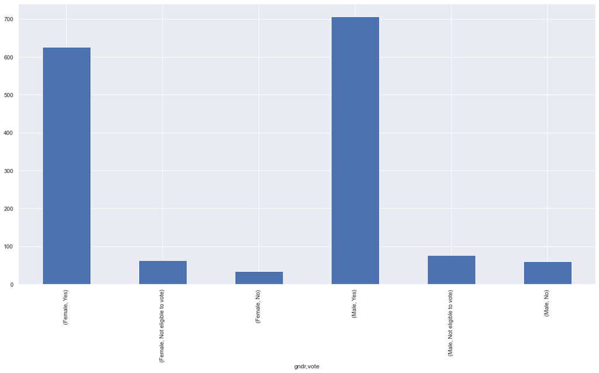

```python
grouped_df['vote'].value_counts().plot.bar()
```

Ovenstående plot er ikke så kønt. Fx kunne det give mening at farvelægge efter værdierne i `vote`. Det kan gøres ved at bruge metoden `unstack()` og så danne plottet:

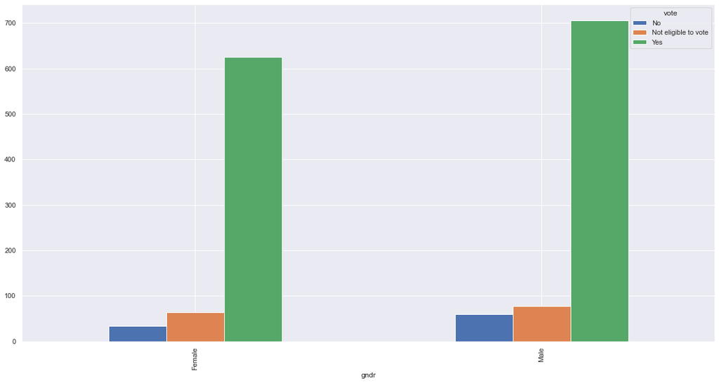

```python
grouped_df['vote'].value_counts().unstack('vote').plot.bar()
```

### Sidenote: Hvad gør `unstack`?

`unstack()` er en metode, der bruges til såkaldt "wide"-konvertering.

Hvis vi først ser på `value_counts()`, gives tællinger i long format; altså hvor hver række er en optælling, og optællingerne differentieres med en kolonne (`vote`).

```python
grouped_df['vote'].value_counts()
```

```
gndr    vote
Female  Yes                     626
        Not eligible to vote     63
        No                       34
Male    Yes                     706
        Not eligible to vote     77
        No                       60
Name: vote, dtype: int64
```

`unstack()` tager værdierne fra `vote` og laver dem til kolonner. På den måde dannes der kun én række per gruppe, hvor værdier adskilles i kolonnerne (wide-format):

```python
grouped_df['vote'].value_counts().unstack('vote')
```

| vote gndr | No | Not eligible to vote | Yes |
| --- | --- | --- | --- |
| Female | 34 | 63 | 626 |
| Male | 60 | 77 | 706 |

Når sådan en tabel plottes med `.plot.bar()` farvelægges der efter kolonneværdierne automatisk.

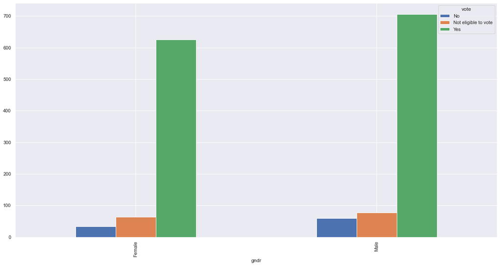

```python
grouped_df['vote'].value_counts().unstack('vote').plot.bar()
```

# ØVELSE 4: VISUALISER GRUPPERINGER

Dan en visualisering, der viser det gennemsnitlige antal arbejdstimer om ugen for mænd og kvinder i datasættet.

# Hvordan er dataframes opbygget?

Lad os se nærmere på, hvordan en dataframe er opbygget.

Kort sagt består dataframes af rækker (index) og kolonner (series).

## Kolonner (`Series`) i en dataframe

En pandas `Series` er en en-dimensionel datastruktur; svarende til en kolonne eller en variabel.

En enkelt `Series` kan lagres som sit eget objekt. Hermed kan vi se, at typen ændrer sig fra "dataframe" til "series".

```python
ess2018_vote = ess2018['vote']
type(ess2018)
```

```
pandas.core.frame.DataFrame
```

```python
type(ess2018_vote)
```

```
pandas.core.series.Series
```

### Series og metoder

Bemærk, at mange af de metoder, som vi har brugt indtil videre, bliver kaldt på en enkelt variabel (`Series`), og ikke et helt datasæt.

Husk at Python metoder er relateret til bestemte objekter. Når man bruger fx metoder, så vær opmærksom på, om I forsøger at gøre det på et helt datasæt eller en enkelt `Series`.

### Series og Python lister

`Series` er på mange måder kompatible med Python lister. Python lister er en grundlæggende datastruktur, som kan være brugbar i mange sammenhænge.

Man kan altid tvinge en `Series` om til at være en liste med funktionen `list()`:

```python
ess2018_votelist = list(ess2018_vote)
print(ess2018_votelist)
```

```
['Yes', 'Yes', nan, 'Not eligible to vote', 'Yes', 'Yes', 'Yes', 'Yes', 'Yes', 'Yes', 'Yes', 'Yes', 'Yes', 'Yes', 'Yes', 'Yes', 'Yes', 'Yes', 'Yes', 'Yes', 'Yes', 'Yes', 'Yes', 'Yes', 'Yes', 'Yes', 'Yes', 'No', 'Yes', 'Yes', 'Yes', 'Yes', 'Yes', 'Yes', 'Yes', 'Yes', 'Yes', 'Yes', 'Yes', 'Yes', 'No',…
```

Omvendt kan man også tvinge en liste om til at være en `Series` med `pd.Series`.

```python
ess2018_voteseries = pd.Series(ess2018_votelist)
print(ess2018_voteseries)
```

```
0                        Yes
1                        Yes
2                        NaN
3       Not eligible to vote
4                        Yes
                ...
1567    Not eligible to vote
1568                     Yes
1569                     Yes
1570                     Yes
1571                      No
Length: 1572, dtype: object
```

## Index i en dataframe

Et "indeks" er en generel betegnelse i Python for værdiers ID, så at sige.

I en dataframe bruges index til at referere til rækkenavnene. Disse kan ses af `.index`:

```python
list(ess2018.index)[0:10]
```

```
[0, 1, 2, 3, 4, 5, 6, 7, 8, 9]
```

Index i Python starter ved 0. Den første række i en dataframe har derfor index 0.

Et index behøver dog ikke være rækkenumre, da man altid kan ændre index-værdierne.

### Index i groupby

Husk at vi ofte arbejder med mange objekter på en gang i Python. Når vi fx bruger `.groupby()` får vi returneret et groupby objekt, uden at ændre på det oprindelige data.

Når så vi bruger en metode som fx `.value_counts` på et groupby objekt, så får vi en ny datastruktur returneret. Denne ligner en dataframe, men faktisk er det blot en enkelt kolonne (`Series`) med et index, der refererer til de forskellige grupperinger.

### Index i en `Series`

I en enkelt `Series`, kan man refere til et bestemt index med `[]` (ligesom ved en Python liste):

```python
ess2018_voteseries[10]
```

```
'Yes'
```

# Subsetting

"Subsetting" vil sige at udvælge specifikke dele af data.

Man subsetter pandas med metoderne `.loc()` og `.iloc()`. `.loc()` bruges til at subsette ud fra række- og kolonnenavne, mens `.iloc()` bruges til at subsette ud fra række- og kolnneindeks.

Format for subsetting: `data.loc[rækker, kolonner]`

Selekter bestemte rækker:

```python
ess2018.loc[2:10, :]
```

|  | idno | netustm | ppltrst | vote | prtvtddk | lvpntyr | tygrtr | gndr | yrbrn | edlvddk | eduyrs | wkhct | wkhtot | grspnum | frlgrsp | inwtm |
| --- | --- | --- | --- | --- | --- | --- | --- | --- | --- | --- | --- | --- | --- | --- | --- | --- |
| 2 | 1327 | 240.0 | 5.0 | NaN | NaN | Still in parental home, never left 2 months | NaN | Male | 2000 | Folkeskole 9.-10. klasse | 11.0 | 37.0 | 37.0 | NaN | NaN | 37.0 |
| 3 | 3760 | 300.0 | 7.0 | Not eligible to vote | NaN | Still in parental home, never left 2 months | 40 | Male | 2002 | Folkeskole 9.-10. klasse | 9.0 | 2.0 | 2.0 | 200.0 | NaN | 43.0 |
| 4 | 4658 | 90.0 | 8.0 | Yes | NaN | 1974 | 50 | Female | 1956 | Kort videregående uddannelse af op til 2-3 års... | 4.0 | 30.0 | 30.0 | NaN | NaN | 62.0 |
| 5 | 5816 | 90.0 | 7.0 | Yes | SF Socialistisk Folkeparti - Socialist People'... | 1994 | 60 | Male | 1974 | Mellemlang videregående uddannelse af 3-4 års ... | 35.0 | 37.0 | 37.0 | 37000.0 | 35000.0 | 61.0 |
| 6 | 7251 | 300.0 | 5.0 | Yes | Dansk Folkeparti - Danish People's Party | 1993 | 40 | Female | 1975 | Faglig uddannelse (håndværk, handel, landbrug ... | 13.0 | 32.0 | 34.0 | 22000.0 | 30000.0 | 68.0 |
| 7 | 7887 | 360.0 | 8.0 | Yes | Socialdemokratiet - The Social democrats | 1983 | 55 | Male | 1958 | Lang videregående uddannelse. Kandidatuddannel... | 25.0 | 39.0 | 39.0 | 36000.0 | 42000.0 | 89.0 |
| 8 | 9607 | 540.0 | 9.0 | Yes | Alternativet - The Alternative | 1982 | 64 | Female | 1964 | Mellemlang videregående uddannelse af 3-4 års ... | 13.0 | 32.0 | 34.0 | 32000.0 | NaN | 50.0 |
| 9 | 11123 | 150.0 | 7.0 | Yes | Socialdemokratiet - The Social democrats | 1994 | 45 | Male | 1974 | Faglig uddannelse (håndværk, handel, landbrug ... | 16.0 | 37.0 | 37.0 | 9000.0 | NaN | 62.0 |
| 10 | 11688 | NaN | 5.0 | Yes | Socialdemokratiet - The Social democrats | 1968 | 50 | Female | 1952 | Faglig uddannelse (håndværk, handel, landbrug ... | 2.0 | 37.0 | 37.0 | NaN | NaN | 77.0 |

Selekter bestemte kolonner (specificeres som en liste):

```python
ess2018.loc[:, ['gndr', 'vote']].head()
```

|  | gndr | vote |
| --- | --- | --- |
| 0 | Male | Yes |
| 1 | Male | Yes |
| 2 | Male | NaN |
| 3 | Male | Not eligible to vote |
| 4 | Female | Yes |

Selekter bestemte rækker og kolonner:

```python
ess2018.loc[2:10, ['gndr', 'vote']]
```

|  | gndr | vote |
| --- | --- | --- |
| 2 | Male | NaN |
| 3 | Male | Not eligible to vote |
| 4 | Female | Yes |
| 5 | Male | Yes |
| 6 | Female | Yes |
| 7 | Male | Yes |
| 8 | Female | Yes |
| 9 | Male | Yes |
| 10 | Female | Yes |

Selekter ud fra kolonneindeks:

```python
ess2018.iloc[2:10, [8, 5]]
```

|  | yrbrn | lvpntyr |
| --- | --- | --- |
| 2 | 2000 | Still in parental home, never left 2 months |
| 3 | 2002 | Still in parental home, never left 2 months |
| 4 | 1956 | 1974 |
| 5 | 1974 | 1994 |
| 6 | 1975 | 1993 |
| 7 | 1958 | 1983 |
| 8 | 1964 | 1982 |
| 9 | 1974 | 1994 |

Bemærk at datasæt ikke ændres. Hvis subset skal gemmes, skal det gemmes i et nyt objekt (ny dataframe):

```python
ess2018_subset = ess2018.loc[2:10, ['gndr', 'vote']]

ess2018_subset.head()
```

|  | gndr | vote |
| --- | --- | --- |
| 2 | Male | NaN |
| 3 | Male | Not eligible to vote |
| 4 | Female | Yes |
| 5 | Male | Yes |
| 6 | Female | Yes |

## Subsetting med booleans (logiske værdier)

I stedet for at specificere indeksnumrene, kan man i stedet specificere betingelser:

```python
ess2018.loc[ess2018['eduyrs'] > 10, :].head()
```

|  | idno | netustm | ppltrst | vote | prtvtddk | lvpntyr | tygrtr | gndr | yrbrn | edlvddk | eduyrs | wkhct | wkhtot | grspnum | frlgrsp | inwtm |
| --- | --- | --- | --- | --- | --- | --- | --- | --- | --- | --- | --- | --- | --- | --- | --- | --- |
| 1 | 705 | 60.0 | 5.0 | Yes | Det Konservative Folkeparti - Conservative Peo... | 1976 | 67 | Male | 1958 | Kort videregående uddannelse af op til 2-3 års... | 22.0 | 37.0 | 45.0 | NaN | NaN | 55.0 |
| 2 | 1327 | 240.0 | 5.0 | NaN | NaN | Still in parental home, never left 2 months | NaN | Male | 2000 | Folkeskole 9.-10. klasse | 11.0 | 37.0 | 37.0 | NaN | NaN | 37.0 |
| 5 | 5816 | 90.0 | 7.0 | Yes | SF Socialistisk Folkeparti - Socialist People'... | 1994 | 60 | Male | 1974 | Mellemlang videregående uddannelse af 3-4 års ... | 35.0 | 37.0 | 37.0 | 37000.0 | 35000.0 | 61.0 |
| 6 | 7251 | 300.0 | 5.0 | Yes | Dansk Folkeparti - Danish People's Party | 1993 | 40 | Female | 1975 | Faglig uddannelse (håndværk, handel, landbrug ... | 13.0 | 32.0 | 34.0 | 22000.0 | 30000.0 | 68.0 |
| 7 | 7887 | 360.0 | 8.0 | Yes | Socialdemokratiet - The Social democrats | 1983 | 55 | Male | 1958 | Lang videregående uddannelse. Kandidatuddannel... | 25.0 | 39.0 | 39.0 | 36000.0 | 42000.0 | 89.0 |

```python
ess2018.loc[(ess2018['eduyrs'] > 10) & (ess2018['gndr'] == 'Female'), :].head()
```

|  | idno | netustm | ppltrst | vote | prtvtddk | lvpntyr | tygrtr | gndr | yrbrn | edlvddk | eduyrs | wkhct | wkhtot | grspnum | frlgrsp | inwtm |
| --- | --- | --- | --- | --- | --- | --- | --- | --- | --- | --- | --- | --- | --- | --- | --- | --- |
| 6 | 7251 | 300.0 | 5.0 | Yes | Dansk Folkeparti - Danish People's Party | 1993 | 40 | Female | 1975 | Faglig uddannelse (håndværk, handel, landbrug ... | 13.0 | 32.0 | 34.0 | 22000.0 | 30000.0 | 68.0 |
| 8 | 9607 | 540.0 | 9.0 | Yes | Alternativet - The Alternative | 1982 | 64 | Female | 1964 | Mellemlang videregående uddannelse af 3-4 års ... | 13.0 | 32.0 | 34.0 | 32000.0 | NaN | 50.0 |
| 13 | 17504 | 210.0 | 4.0 | Yes | Dansk Folkeparti - Danish People's Party | 2001 | 45 | Female | 1984 | Faglig uddannelse (håndværk, handel, landbrug ... | 13.0 | NaN | 10.0 | NaN | NaN | 51.0 |
| 14 | 19970 | 240.0 | 9.0 | Yes | Liberal Alliance - Liberal Alliance | 1984 | 60 | Female | 1966 | Lang videregående uddannelse. Kandidatuddannel... | 21.0 | 36.0 | 36.0 | 85000.0 | NaN | 42.0 |
| 16 | 22248 | 121.0 | 9.0 | Yes | Socialdemokratiet - The Social democrats | 1970 | Never too young | Female | 1950 | Mellemlang videregående uddannelse af 3-4 års ... | 19.0 | 37.0 | 37.0 | NaN | NaN | 62.0 |

# ØVELSE 5: SUBSETTING

*Dan et subset bestående af alle kvinder med en månedlig indkomst over 40.000 (`grspnum`).*

# Nye variable

Ofte har man brug for at tilføje oplysninger til et datasæt i form af nye variable.

Man danner en ny variabel blot ved at referere til et kolonnenavn, som endnu ikke er brugt.

I nedenstående dannes en variabel for interviewlængde i timer:

```python
ess2018['inwth'] = ess2018['inwtm'] / 60

ess2018.head()
```

|  | idno | netustm | ppltrst | vote | prtvtddk | lvpntyr | tygrtr | gndr | yrbrn | edlvddk | eduyrs | wkhct | wkhtot | grspnum | frlgrsp | inwtm | inwth |
| --- | --- | --- | --- | --- | --- | --- | --- | --- | --- | --- | --- | --- | --- | --- | --- | --- | --- |
| 0 | 110 | 180.0 | 8.0 | Yes | Socialdemokratiet - The Social democrats | 1968 | Never too young | Male | 1949 | Kort videregående uddannelse af op til 2-3 års... | 9.0 | 28.0 | 28.0 | NaN | NaN | 119.0 | 1.983333 |
| 1 | 705 | 60.0 | 5.0 | Yes | Det Konservative Folkeparti - Conservative Peo... | 1976 | 67 | Male | 1958 | Kort videregående uddannelse af op til 2-3 års... | 22.0 | 37.0 | 45.0 | NaN | NaN | 55.0 | 0.916667 |
| 2 | 1327 | 240.0 | 5.0 | NaN | NaN | Still in parental home, never left 2 months | NaN | Male | 2000 | Folkeskole 9.-10. klasse | 11.0 | 37.0 | 37.0 | NaN | NaN | 37.0 | 0.616667 |
| 3 | 3760 | 300.0 | 7.0 | Not eligible to vote | NaN | Still in parental home, never left 2 months | 40 | Male | 2002 | Folkeskole 9.-10. klasse | 9.0 | 2.0 | 2.0 | 200.0 | NaN | 43.0 | 0.716667 |
| 4 | 4658 | 90.0 | 8.0 | Yes | NaN | 1974 | 50 | Female | 1956 | Kort videregående uddannelse af op til 2-3 års... | 4.0 | 30.0 | 30.0 | NaN | NaN | 62.0 | 1.033333 |

## Rekodning

Ofte har man brug for at rekode variable.

Variable rekodes ved at overskrive værdier i en eksisterende variabel.

Det er god praksis ikke at rekode de oprindelige variable i datasættet, så man vil i stedet lave en kopi af variablen og så rekode den i stedet.

Hvis man fx vil rekode en kontinuerlig variabel til kategorisk, kan man gøre brug af booleans.

I nedenstående inddeles personer i datasættet i tre indkomstgrupper baseret på, om de har en indkomst under 1. kvartil ("low"), over 3. kvartil ("high") eller midt imellem ("medium").

```python
import numpy as np

quart1 = ess2018['grspnum'].quantile(0.25)
quart3 = ess2018['grspnum'].quantile(0.75)

ess2018['grsp_cat'] = np.nan # Danner en "tom" variabel bestående af missing

ess2018.loc[ess2018['grspnum'] <= quart1, 'grsp_cat'] = "low"
ess2018.loc[(ess2018['grspnum'] > quart1) & (ess2018['grspnum'] < quart3), 'grsp_cat'] = "medium"
ess2018.loc[ess2018['grspnum'] >= quart3, 'grsp_cat'] = "high"

ess2018.head(10)
```

|  | idno | netustm | ppltrst | vote | prtvtddk | lvpntyr | tygrtr | gndr | yrbrn | edlvddk | eduyrs | wkhct | wkhtot | grspnum | frlgrsp | inwtm | inwth | grsp_cat |
| --- | --- | --- | --- | --- | --- | --- | --- | --- | --- | --- | --- | --- | --- | --- | --- | --- | --- | --- |
| 0 | 110 | 180.0 | 8.0 | Yes | Socialdemokratiet - The Social democrats | 1968 | Never too young | Male | 1949 | Kort videregående uddannelse af op til 2-3 års... | 9.0 | 28.0 | 28.0 | NaN | NaN | 119.0 | 1.983333 | NaN |
| 1 | 705 | 60.0 | 5.0 | Yes | Det Konservative Folkeparti - Conservative Peo... | 1976 | 67 | Male | 1958 | Kort videregående uddannelse af op til 2-3 års... | 22.0 | 37.0 | 45.0 | NaN | NaN | 55.0 | 0.916667 | NaN |
| 2 | 1327 | 240.0 | 5.0 | NaN | NaN | Still in parental home, never left 2 months | NaN | Male | 2000 | Folkeskole 9.-10. klasse | 11.0 | 37.0 | 37.0 | NaN | NaN | 37.0 | 0.616667 | NaN |
| 3 | 3760 | 300.0 | 7.0 | Not eligible to vote | NaN | Still in parental home, never left 2 months | 40 | Male | 2002 | Folkeskole 9.-10. klasse | 9.0 | 2.0 | 2.0 | 200.0 | NaN | 43.0 | 0.716667 | low |
| 4 | 4658 | 90.0 | 8.0 | Yes | NaN | 1974 | 50 | Female | 1956 | Kort videregående uddannelse af op til 2-3 års... | 4.0 | 30.0 | 30.0 | NaN | NaN | 62.0 | 1.033333 | NaN |
| 5 | 5816 | 90.0 | 7.0 | Yes | SF Socialistisk Folkeparti - Socialist People'... | 1994 | 60 | Male | 1974 | Mellemlang videregående uddannelse af 3-4 års ... | 35.0 | 37.0 | 37.0 | 37000.0 | 35000.0 | 61.0 | 1.016667 | medium |
| 6 | 7251 | 300.0 | 5.0 | Yes | Dansk Folkeparti - Danish People's Party | 1993 | 40 | Female | 1975 | Faglig uddannelse (håndværk, handel, landbrug ... | 13.0 | 32.0 | 34.0 | 22000.0 | 30000.0 | 68.0 | 1.133333 | low |
| 7 | 7887 | 360.0 | 8.0 | Yes | Socialdemokratiet - The Social democrats | 1983 | 55 | Male | 1958 | Lang videregående uddannelse. Kandidatuddannel... | 25.0 | 39.0 | 39.0 | 36000.0 | 42000.0 | 89.0 | 1.483333 | medium |
| 8 | 9607 | 540.0 | 9.0 | Yes | Alternativet - The Alternative | 1982 | 64 | Female | 1964 | Mellemlang videregående uddannelse af 3-4 års ... | 13.0 | 32.0 | 34.0 | 32000.0 | NaN | 50.0 | 0.833333 | medium |
| 9 | 11123 | 150.0 | 7.0 | Yes | Socialdemokratiet - The Social democrats | 1994 | 45 | Male | 1974 | Faglig uddannelse (håndværk, handel, landbrug ... | 16.0 | 37.0 | 37.0 | 9000.0 | NaN | 62.0 | 1.033333 | low |

```python
ess2018['grsp_cat'] = pd.cut(ess2018['grspnum'], 3, labels = ["low", "medium", "high"])

ess2018.head(10)
```

|  | idno | netustm | ppltrst | vote | prtvtddk | lvpntyr | tygrtr | gndr | yrbrn | edlvddk | eduyrs | wkhct | wkhtot | grspnum | frlgrsp | inwtm | inwth | grsp_cat |
| --- | --- | --- | --- | --- | --- | --- | --- | --- | --- | --- | --- | --- | --- | --- | --- | --- | --- | --- |
| 0 | 110 | 180.0 | 8.0 | Yes | Socialdemokratiet - The Social democrats | 1968 | Never too young | Male | 1949 | Kort videregående uddannelse af op til 2-3 års... | 9.0 | 28.0 | 28.0 | NaN | NaN | 119.0 | 1.983333 | NaN |
| 1 | 705 | 60.0 | 5.0 | Yes | Det Konservative Folkeparti - Conservative Peo... | 1976 | 67 | Male | 1958 | Kort videregående uddannelse af op til 2-3 års... | 22.0 | 37.0 | 45.0 | NaN | NaN | 55.0 | 0.916667 | NaN |
| 2 | 1327 | 240.0 | 5.0 | NaN | NaN | Still in parental home, never left 2 months | NaN | Male | 2000 | Folkeskole 9.-10. klasse | 11.0 | 37.0 | 37.0 | NaN | NaN | 37.0 | 0.616667 | NaN |
| 3 | 3760 | 300.0 | 7.0 | Not eligible to vote | NaN | Still in parental home, never left 2 months | 40 | Male | 2002 | Folkeskole 9.-10. klasse | 9.0 | 2.0 | 2.0 | 200.0 | NaN | 43.0 | 0.716667 | low |
| 4 | 4658 | 90.0 | 8.0 | Yes | NaN | 1974 | 50 | Female | 1956 | Kort videregående uddannelse af op til 2-3 års... | 4.0 | 30.0 | 30.0 | NaN | NaN | 62.0 | 1.033333 | NaN |
| 5 | 5816 | 90.0 | 7.0 | Yes | SF Socialistisk Folkeparti - Socialist People'... | 1994 | 60 | Male | 1974 | Mellemlang videregående uddannelse af 3-4 års ... | 35.0 | 37.0 | 37.0 | 37000.0 | 35000.0 | 61.0 | 1.016667 | low |
| 6 | 7251 | 300.0 | 5.0 | Yes | Dansk Folkeparti - Danish People's Party | 1993 | 40 | Female | 1975 | Faglig uddannelse (håndværk, handel, landbrug ... | 13.0 | 32.0 | 34.0 | 22000.0 | 30000.0 | 68.0 | 1.133333 | low |
| 7 | 7887 | 360.0 | 8.0 | Yes | Socialdemokratiet - The Social democrats | 1983 | 55 | Male | 1958 | Lang videregående uddannelse. Kandidatuddannel... | 25.0 | 39.0 | 39.0 | 36000.0 | 42000.0 | 89.0 | 1.483333 | low |
| 8 | 9607 | 540.0 | 9.0 | Yes | Alternativet - The Alternative | 1982 | 64 | Female | 1964 | Mellemlang videregående uddannelse af 3-4 års ... | 13.0 | 32.0 | 34.0 | 32000.0 | NaN | 50.0 | 0.833333 | low |
| 9 | 11123 | 150.0 | 7.0 | Yes | Socialdemokratiet - The Social democrats | 1994 | 45 | Male | 1974 | Faglig uddannelse (håndværk, handel, landbrug ... | 16.0 | 37.0 | 37.0 | 9000.0 | NaN | 62.0 | 1.033333 | low |

## Missingværdier

Missing værdier er angivet med `NaN`. Man kan undersøge, om en variabel indeholder missing, ved at bruge metoden `isnull()`:

```python
ess2018['grspnum'].isnull().head()
```

```
0     True
1     True
2     True
3    False
4     True
Name: grspnum, dtype: bool
```

Denne kan også bruges i `.loc[]`:

```python
ess2018.loc[ess2018['grspnum'].isnull(), :].head()
```

|  | idno | netustm | ppltrst | vote | prtvtddk | lvpntyr | tygrtr | gndr | yrbrn | edlvddk | eduyrs | wkhct | wkhtot | grspnum | frlgrsp | inwtm | inwth | grsp_cat |
| --- | --- | --- | --- | --- | --- | --- | --- | --- | --- | --- | --- | --- | --- | --- | --- | --- | --- | --- |
| 0 | 110 | 180.0 | 8.0 | Yes | Socialdemokratiet - The Social democrats | 1968 | Never too young | Male | 1949 | Kort videregående uddannelse af op til 2-3 års... | 9.0 | 28.0 | 28.0 | NaN | NaN | 119.0 | 1.983333 | NaN |
| 1 | 705 | 60.0 | 5.0 | Yes | Det Konservative Folkeparti - Conservative Peo... | 1976 | 67 | Male | 1958 | Kort videregående uddannelse af op til 2-3 års... | 22.0 | 37.0 | 45.0 | NaN | NaN | 55.0 | 0.916667 | NaN |
| 2 | 1327 | 240.0 | 5.0 | NaN | NaN | Still in parental home, never left 2 months | NaN | Male | 2000 | Folkeskole 9.-10. klasse | 11.0 | 37.0 | 37.0 | NaN | NaN | 37.0 | 0.616667 | NaN |
| 4 | 4658 | 90.0 | 8.0 | Yes | NaN | 1974 | 50 | Female | 1956 | Kort videregående uddannelse af op til 2-3 års... | 4.0 | 30.0 | 30.0 | NaN | NaN | 62.0 | 1.033333 | NaN |
| 10 | 11688 | NaN | 5.0 | Yes | Socialdemokratiet - The Social democrats | 1968 | 50 | Female | 1952 | Faglig uddannelse (håndværk, handel, landbrug ... | 2.0 | 37.0 | 37.0 | NaN | NaN | 77.0 | 1.283333 | NaN |

# ØVELSE 6: NYE VARIABLE OG REKODNING